# Rmarkdown_new

Alan S

2024-06-22

## Driving Simulation Alcohol Results

Below are some comparisons of various driving and vision metrics comparing when you drove with a blood alcohol content (BAC) of about 0.050% to when you were sober. Please take a moment to consider how affected your driving performance and perception may be, at a BAC level equivalent to the maximum that is legally accepted.

**NOTE:** Please be aware that the results below are from a single, lab-controlled experiment and may not generalise to actual driving performance and behaviour. In Australia, it is illegal to drive with a BAC of 0.050% or above, for most drivers on their open license.

## Eye-Tracking

While you were driving, infrared cameras were tracking where you were looking throughout. The heatmaps below show a trend on where you spent most of your time looking between the varying alcohol conditions. The darker the circle, the more fixations you made in that area. The pictures below show how your spread of gaze differed between the conditions

Standard Deviations of x and y by Trial

| trial | sd_x | sd_y |
| --- | --- | --- |
| alc_0.00 | 0.0829696 | 0.1132132 |
| alc_0.05 | 0.1185340 | 0.1260906 |
| alc_0.08 | 0.1071944 | 0.1078665 |

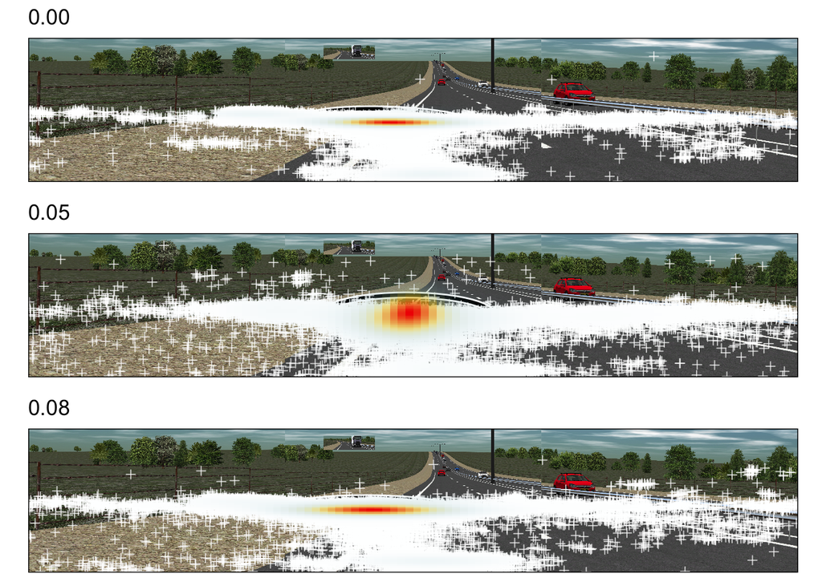

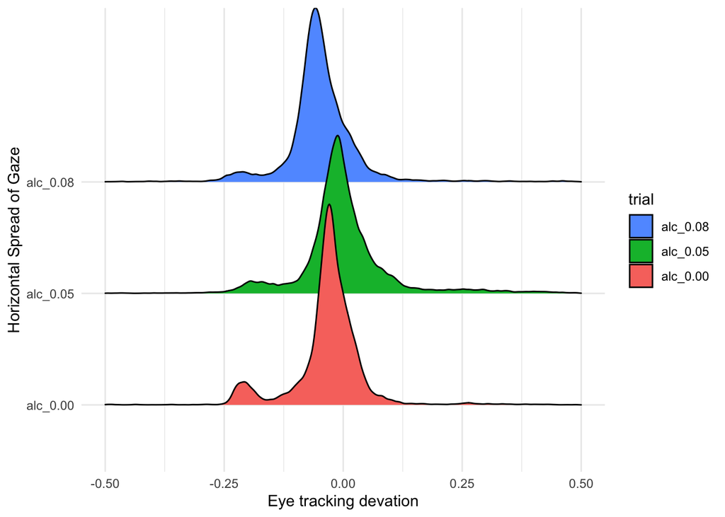

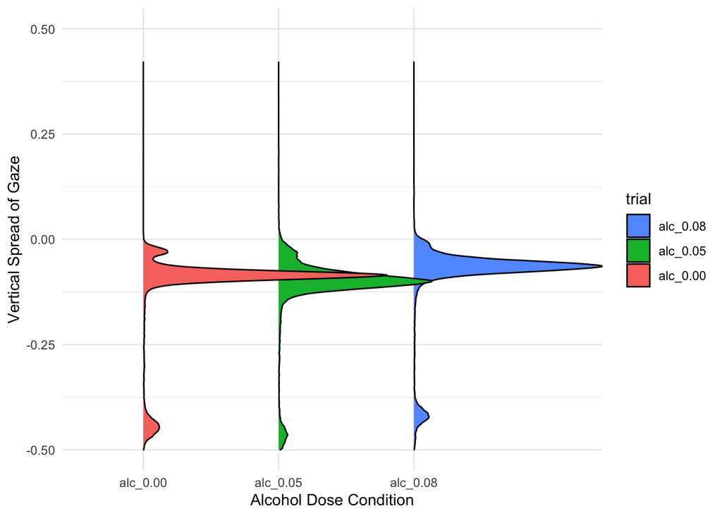

## Driving Metrics

### Speed

Your speed was measured throughout the drive. Excluding section one where you were required to follow behind a car, your average speed in the placebo condition was **114.34km/h**, your average speed in the 0.05% BAC condition was **119.51km/h**, and your average speed in the 0.08% BAC condition was **118.26km/h**.

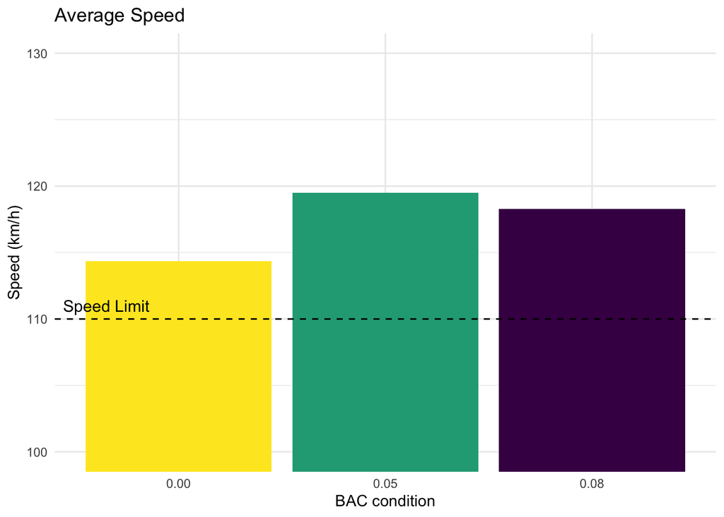

It is also important to understand how much of the drive you spent exceeding the speed limit. Although the speed limit was 110km/h we have chosen 115km/h as the speed cutoff here to allow for times when the driver might be only a couple of km/h over the speed limit unintentionally. Once again, this excluded the ‘car following’ portion of the drive, as your speeds were governed by the task of following the vehicle in front.

In the placebo condition you spent **41.1%** of the drive in excess of 115km/h. In the 0.05% BAC condition, you spent **93.25%** of the drive in excess of 115km/h. In the 0.08% BAC condition, you spent **72.02%** of the drive in excess of 115km/h.

As you can see, you spent far more time speeding when driving after consuming alcohol compared to when you had consumed no alcohol.

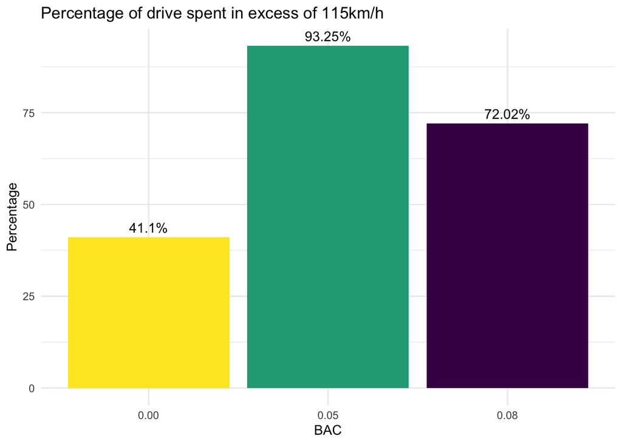

### Standard Deviation of Speed

In the context of driving, the standard deviation of speed can be thought of as a measure of how much individual speeds vary from the average (mean) speed. It provides an indication of the spread or dispersion of speeds. A low standard deviation suggests that the speed stayed relatively consistent or similar, while a high standard deviation suggests a greater diversity in speeds throughout the drive. Excluding section one where you were required to follow behind a car whose speed was programmed to speed up and slow down, your standard deviation of speed in the placebo condition was **2.98**, your standard deviation of speed in the 0.05% BAC condition was **4.38**, and your standard deviation of speed in the 0.08% BAC condition was **6.36**. Your standard deviation of speed was highest in the 0.08% condition, indicating that the higher your BAC, the more trouble you had maintaining a consistent speed.

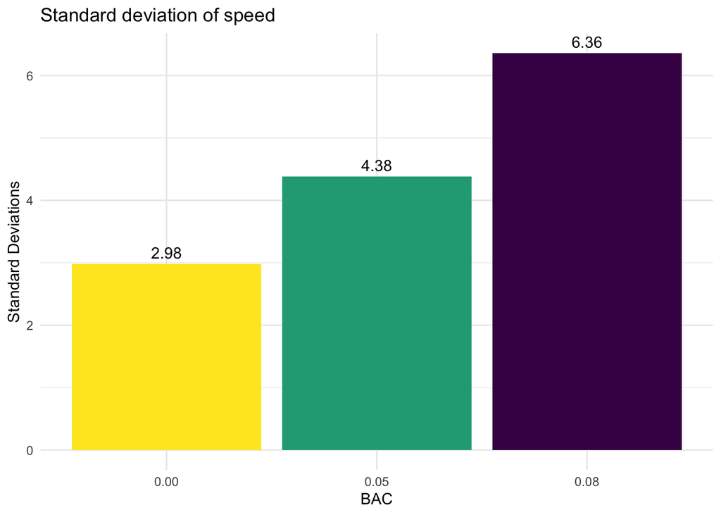

### Standard deviation of lateral position

In the context of driving, the standard deviation of lateral position (SDLP) refers to a measure of how much your vehicle deviated or varies from its expected position on the center of the road. An SDLP of zero would mean that the vehicle stays perfectly in the center of the lane, while positive or negative values of SDLP suggests more variation in lateral position, indicating a less stable or more variable driving behavior (i.e. swerving).

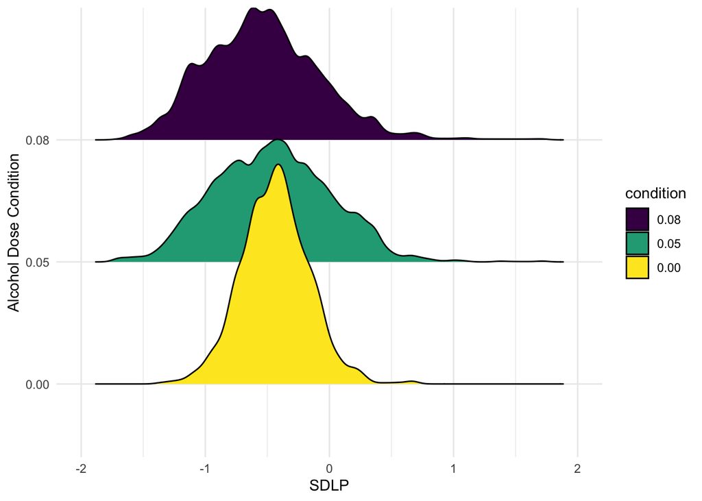

### Car Following Task

For the first section of the highway drive, you were tasked with trying to maintain a consistent distance from the car in front.  
As you can see on the plot below, your following distance became a shorter when you had consumed more alcohol. In the placebo condition (green), your average following distance was **103.69 metres**. When your BAC was around 0.05% (yellow), your average following distance was **50.88 metres**, and when your BAC was about 0.08% (red), your average following distance was **25.6 metres**.

In addition to the car following distance, we also measured speed coherence, which is how well you could maintain a consistent distance from the car in front, as it sped up and slowed down. Scores range from 0-1, and a perfect speed coherence score would be 1, meaning you perfectly matched the car in fronts speed for the entirety of the car following task. Your speed coherence for the three conditions were:

0.00% BAC condition: 0.05  
0.05% BAC condition: 0.24  
0.08% BAC condition: 0.69

We also monitored the number of times you veered out of your allocated lane.  
When your BAC was 0.00, you veered out of the lane **8** times.  
When your BAC was 0.05, you veered out of the lane **66** times.  
When your BAC was 0.08, you veered out of the lane **72** times.

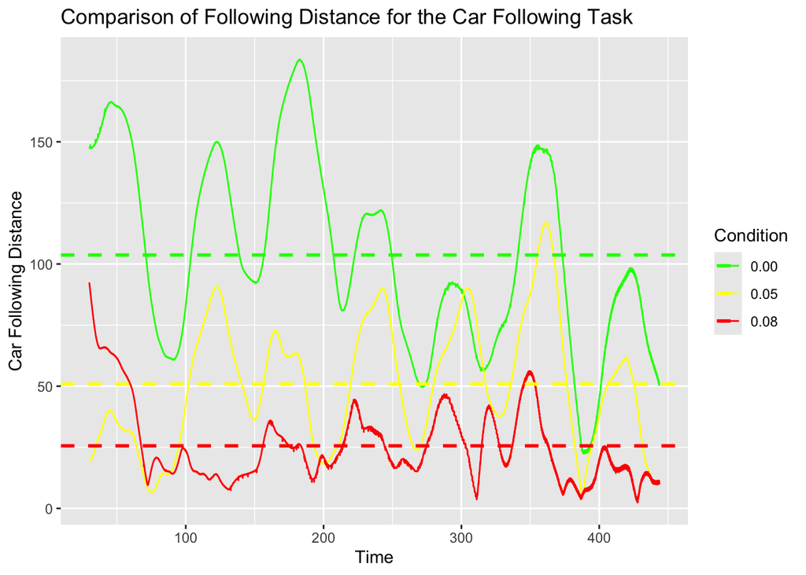

I did have the information here for the cognitive tests but they weren’t very informative.